# SPI Data Validation

Brian Stacy

2025-05-16

# Validation

Now will validate the data the was produced. This will occur in two steps.

First, the overall data set (SPI_data.csv) will be compared to the original dataset published on github. It is natural for some values to change from this vintage compared to last vintage, as the underlying data sources have been updated. However, this comparison will systematically monitor the differences and potentially highlight unexpected changes. The dataCompareR package will be used for this purpose in R.

Second, the overall data set will be compared to a set of expected values for each column. The exact expected values will be listed below, but the general idea is to check that the values adhere to rational min/max values and positive correlate in expected ways.

## Comparison to Existing Vintage of Data

First the latest vintage of the SPI data is read from the [SPI github repo](https://github.com/worldbank/SPI/blob/master/03_output_data/SPI_data.csv). Next this data is compared automatically to the data that is produced using the current raw data found in the 03_output_data directory in this repo. Comparison is done automatically using the utilities in the [DataCompareR](https://github.com/capitalone/dataCompareR) R package.

```r
SPI_df_v1 <- read_csv('https://raw.githubusercontent.com/worldbank/SPI/master/03_output_data/SPI_data.csv')
SPI_df_new <-  read_csv( file = paste(output_dir, 'SPI_data.csv', sep="/"))
comp_SPI <- rCompare(SPI_df_v1, SPI_df_new, keys = c('iso3c','date'))
```

```
## Running rCompare...
## Coercing input data to data.frame
```

```r
summary(comp_SPI)
```

```
## dataCompareR is generating the summary...
```

```
##
## Data Comparison
## ===============
##
## Date comparison run: 2025-05-16 08:18:18.925477
## Comparison run on R version 4.4.1 (2024-06-14 ucrt)
## With dataCompareR version 0.1.4
##
##
## Meta Summary
## ============
##
##
## |Dataset Name |Number of Rows |Number of Columns |
## |:------------|:--------------|:-----------------|
## |SPI_df_v1    |4340           |117               |
## |SPI_df_new   |4557           |117               |
##
##
## Variable Summary
## ================
##
## Number of columns in common: 117
## Number of columns only in SPI_df_v1: 0
## Number of columns only in SPI_df_new: 0
## Number of columns with a type mismatch: 1
## Match keys : 2   - ISO3C, DATE
##
##
## Listing of Common Columns with Different Data Types
## ===================================================
##
##
##
## |Column Name         |Column Type (in SPI_df_v1) |Column Type (in SPI_df_new) |
## |:-------------------|:--------------------------|:---------------------------|
## |RAW.D5.2.7.CGOV.IMF |logical                    |character                   |
##
##
##
```

[output cut: 718 more lines]

```
##
## No rows were dropped from  SPI_df_v1
##
##
## The following rows were dropped from  SPI_df_new
## Showing sample of size 5
##
##
## |ISO3C | DATE|
## |:-----|----:|
## |MDV   | 2024|
## |BHS   | 2024|
## |CYM   | 2024|
## |KIR   | 2024|
## |HRV   | 2024|
```

# Comparison to Expectations

Next the values of individual columns in the dataset are checked against expectations. The expectations are things like the expected minimum and maximum value of a column in the dataset or expected correlations between variables. For instance, the availability of SDG indicators columns are the fraction of SDG indicators in a goal with a value in the previous 5 years. Thus, they should be between 0 and 1.

The full list of expectations is printed below.

```r
#define the expectations for each column

#set overall rules for number of countries and span of years

cntry_list <- unique(SPI_df_v1$iso3c)


SPI_ind_list_v <- grepl('SPI.', colnames(SPI_df_v1))
SPI_ind_list <- colnames(SPI_df_v1)[SPI_ind_list_v]


rules <- validator(
    countries_included=iso3c %in% cntry_list, #check number of countries included
    dates_covered=date %in% c(2004:end_year), #check dates included

    # check for each country that the dates are available
    dates_by_country=contains_exactly(
      keys=data.frame(date=c(2004:end_year)),
      by=iso3c
    ),

    #go through list of SPI constructed indicators and make sure they are between 0 and 1
    SPI.D1.5.POV_minmax=in_range(SPI.D1.5.POV  ,0,1),
    SPI.D1.5.CHLD.MORT_minmax=in_range(SPI.D1.5.CHLD.MORT  ,0,1),
    SPI.D1.5.DT.TDS.DPPF.XP.ZS_minmax=in_range(SPI.D1.5.DT.TDS.DPPF.XP.ZS   ,0,1),
    SPI.D1.5.SAFE.MAN.WATER_minmax=in_range(SPI.D1.5.SAFE.MAN.WATER   ,0,1),
    SPI.D1.5.LFP_minmax=in_range(SPI.D1.5.LFP     ,0,1),
    SPI.D2.1.GDDS_minmax=in_range(SPI.D2.1.GDDS    ,0,1),
    SPI.D2.2.Machine.readable_minmax=in_range(SPI.D2.2.Machine.readable   ,0,1),
    SPI.D2.2.Non.proprietary_minmax=in_range(SPI.D2.2.Non.proprietary    ,0,1),
    SPI.D2.2.Download.options_minmax=in_range(SPI.D2.2.Download.options   ,0,1),
    SPI.D2.2.Metadata.available_minmax=in_range(SPI.D2.2.Metadata.available  ,0,1),
    SPI.D2.2.Terms.of.use_minmax=in_range(SPI.D2.2.Terms.of.use      ,0,1),
    SPI.D2.2.Openness.subscore_minmax=in_range(SPI.D2.2.Openness.subscore   ,0,1),
    SPI.D2.4.NADA_minmax=in_range(SPI.D2.4.NADA      ,0,1),
    SPI.D3.1.POV_minmax=in_range(SPI.D3.1.POV    ,0,1),
    SPI.D3.2.HNGR_minmax=in_range(SPI.D3.2.HNGR   ,0,1),
    SPI.D3.3.HLTH_minmax=in_range(SPI.D3.3.HLTH    ,0,1),
    SPI.D3.4.EDUC_minmax=in_range(SPI.D3.4.EDUC    ,0,1),
    SPI.D3.5.GEND_minmax=in_range(SPI.D3.5.GEND    ,0,1),
    SPI.D3.6.WTRS_minmax=in_range(SPI.D3.6.WTRS    ,0,1),
    SPI.D3.7.ENRG_minmax=in_range(SPI.D3.7.ENRG   ,0,1),
    SPI.D3.8.WORK_minmax=in_range( SPI.D3.8.WORK    ,0,1),
    SPI.D3.9.INDY_minmax=in_range(SPI.D3.9.INDY    ,0,1),
    SPI.D3.10.NEQL_minmax=in_range(SPI.D3.10.NEQL    ,0,1),
    SPI.D3.11.CITY_minmax=in_range(SPI.D3.11.CITY    ,0,1),
    SPI.D3.12.CNSP_minmax=in_range(SPI.D3.12.CNSP    ,0,1),
    SPI.D3.15.LAND_minmax=in_range(SPI.D3.15.LAND     ,0,1),
    SPI.D3.16.INST_minmax=in_range(SPI.D3.16.INST     ,0,1),
    SPI.D3.17.PTNS_minmax=in_range(SPI.D3.17.PTNS     ,0,1),
    SPI.D3.13.CLMT_minmax=in_range(SPI.D3.13.CLMT     ,0,1),
    SPI.D4.1.1.POPU_minmax=in_range(SPI.D4.1.1.POPU    ,0,1),
    SPI.D4.1.2.AGRI_minmax=in_range(SPI.D4.1.2.AGRI     ,0,1),
    SPI.D4.1.3.BIZZ_minmax=in_range(SPI.D4.1.3.BIZZ     ,0,1),
    SPI.D4.1.4.HOUS_minmax=in_range(SPI.D4.1.4.HOUS     ,0,1),
    SPI.D4.1.5.AGSVY_minmax=in_range(SPI.D4.1.5.AGSVY    ,0,1),
    SPI.D4.1.6.LABR_minmax=in_range(SPI.D4.1.6.LABR      ,0,1),
    SPI.D4.1.7.HLTH_minmax=in_range(SPI.D4.1.7.HLTH      ,0,1),
    SPI.D4.1.8.BZSVY_minmax=in_range(SPI.D4.1.8.BZSVY     ,0,1),
    SPI.D4.2.3.CRVS_minmax=in_range(SPI.D4.2.3.CRVS      ,0,1),
    SPI.D4.3.GEO.first.admin.level_minmax=in_range(SPI.D4.3.GEO.first.admin.level   ,0,1),
    SPI.D4.3.GEO.second.admin.level_minmax=in_range(SPI.D4.3.GEO.second.admin.level  ,0,1),
    SPI.D5.1.DILG_minmax=in_range(SPI.D5.1.DILG     ,0,1),
    SPI.D5.2.1.SNAU_minmax=in_range(SPI.D5.2.1.SNAU   ,0,1),
    SPI.D5.2.2.NABY_minmax=in_range(SPI.D5.2.2.NABY    ,0,1),
    SPI.D5.2.3.CNIN_minmax=in_range(SPI.D5.2.3.CNIN    ,0,1),
    SPI.D5.2.4.CPIBY_minmax=in_range(SPI.D5.2.4.CPIBY    ,0,1),
    SPI.D5.2.5.HOUS_minmax=in_range(SPI.D5.2.5.HOUS    ,0,1),
    SPI.D5.2.6.EMPL_minmax=in_range(SPI.D5.2.6.EMPL     ,0,1),
    SPI.D5.2.7.CGOV_minmax=in_range(SPI.D5.2.7.CGOV    ,0,1),
    SPI.D5.2.8.FINA_minmax=in_range(SPI.D5.2.8.FINA     ,0,1),
    SPI.D5.2.9.MONY_minmax=in_range(SPI.D5.2.9.MONY    ,0,1),
    SPI.D5.2.10.GSBP_minmax=in_range(SPI.D5.2.10.GSBP   ,0,1),
    SPI.D5.3.DISK_minmax=in_range(SPI.D5.3.DISK     ,0,1),
    SPI.D5.5.DIFI_minmax=in_range(SPI.D5.5.DIFI   ,0,1)
)


out  <- confront(SPI_df_new, rules)
summary(out)
```

```
##                                      name items passes fails  nNA error warning
## 1                      countries_included  4557   4557     0    0 FALSE   FALSE
## 2                           dates_covered  4557   4557     0    0 FALSE   FALSE
## 3                        dates_by_country  4557   4557     0    0 FALSE   FALSE
## 4                     SPI.D1.5.POV_minmax  4557   4557     0    0 FALSE   FALSE
## 5               SPI.D1.5.CHLD.MORT_minmax  4557   4557     0    0 FALSE   FALSE
## 6       SPI.D1.5.DT.TDS.DPPF.XP.ZS_minmax  4557   4557     0    0 FALSE   FALSE
## 7          SPI.D1.5.SAFE.MAN.WATER_minmax  4557   4557     0    0 FALSE   FALSE
## 8                     SPI.D1.5.LFP_minmax  4557   4557     0    0 FALSE   FALSE
## 9                    SPI.D2.1.GDDS_minmax  4557   2366     0 2191 FALSE   FALSE
## 10       SPI.D2.2.Machine.readable_minmax  4557   1800     0 2757 FALSE   FALSE
## 11        SPI.D2.2.Non.proprietary_minmax  4557   1800     0 2757 FALSE   FALSE
## 12       SPI.D2.2.Download.options_minmax  4557   1800     0 2757 FALSE   FALSE
## 13     SPI.D2.2.Metadata.available_minmax  4557   1800     0 2757 FALSE   FALSE
## 14           SPI.D2.2.Terms.of.use_minmax  4557   1800     0 2757 FALSE   FALSE
```

[output cut: 99 more lines]

```
## Rules SPI.D5.3.DISK_minmax not included in plot since they could not be executed. See ?errors
```

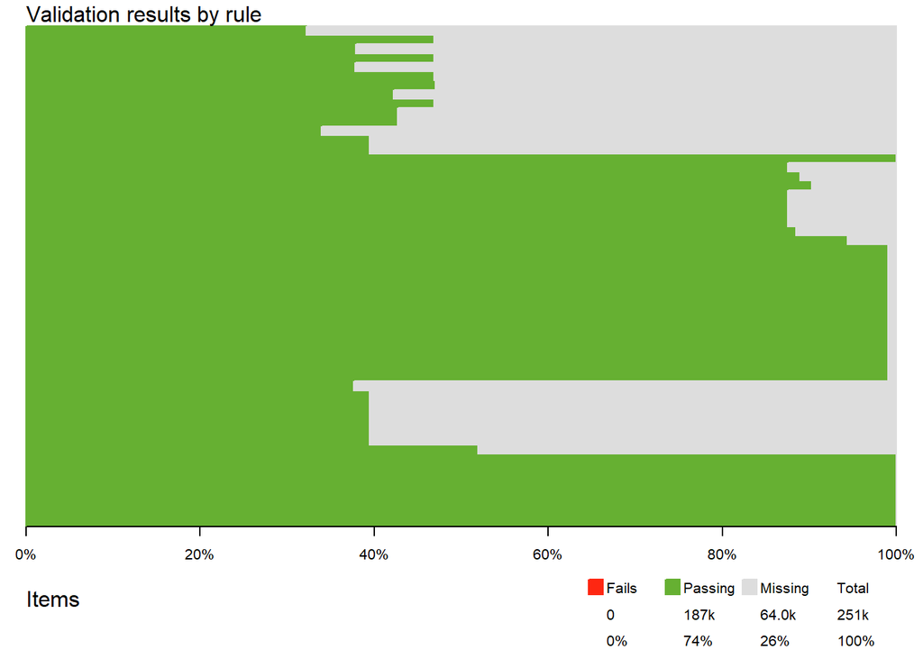

```r
plot(out)
```

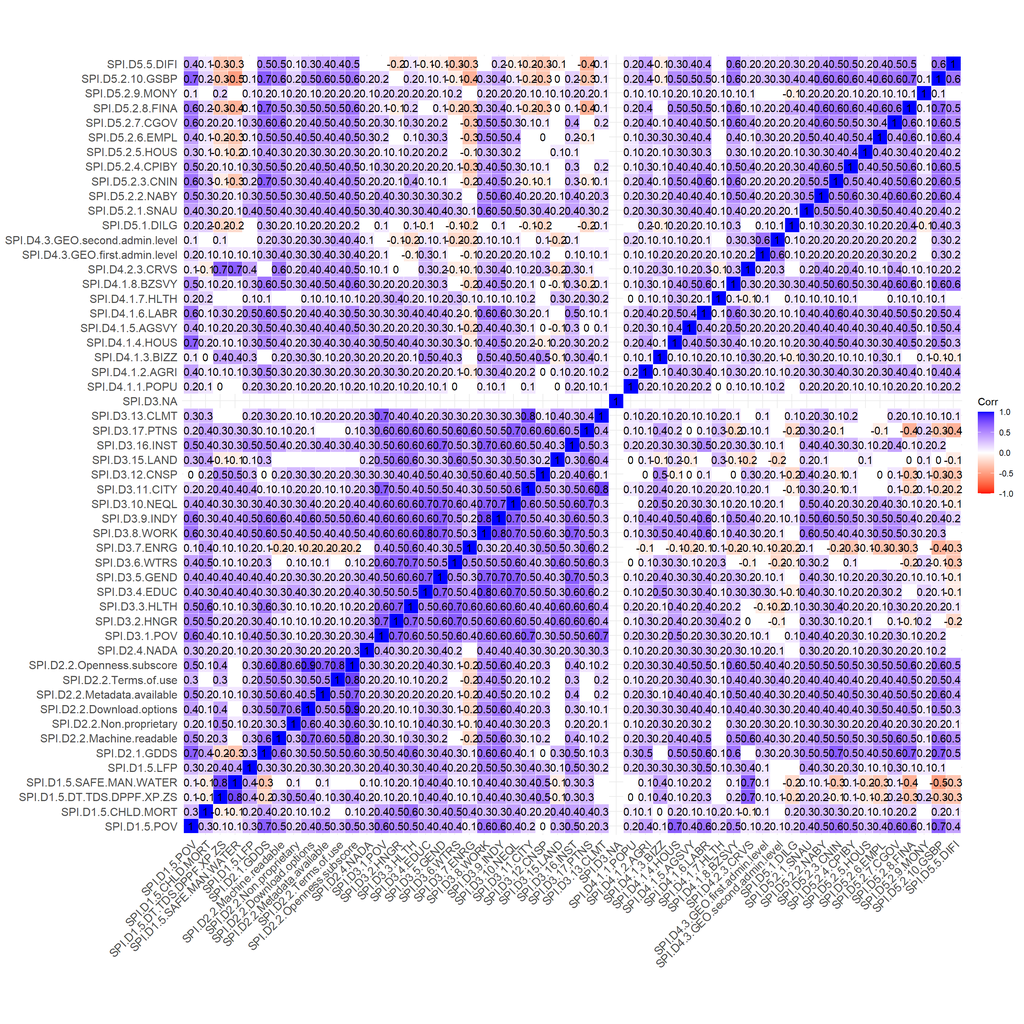

```r
#check the correlations between the indicators

corr_df <- SPI_df_new %>%
  select(SPI_ind_list) %>%
  as.matrix()

cor <- Hmisc::rcorr(corr_df )

cor_df <- round(cor$r,1)
p.mat<-cor_pmat(corr_df)


ggcorrplot(cor_df,   outline.col="white",
           colors=c('red', 'white', 'blue'), p.mat=p.mat,insig = "blank", lab=TRUE, digits=1)
```